# BDB RMD

Jackson Balch

2023-01-07

## Big Data Bowl 2023

## YLAE: A Better Way to Measure Lineman Performance on Pass Plays

Growing up, I was always a bigger kid. From about first grade on to high school, I was the biggest kid in my class by at least 20-30 pounds. There aren’t a whole lot of opportunities or situations where that’s particularly useful or fun at all, but one where it is at least semi-appreciated is the game of football. When I finally made it to the fall of my third grade year, I joined and played my first snaps of PeeWee Football. I dreamed of scoring touchdowns or being the star RB, but alas, the weight limit came into effect. I was over the threshold required to be a “skill” position, so I became a lineman.

Point being here that all my life now, I’ve been a lineman. I’ve watched linemen play again and again, and have been able to formulate my own opinions about what makes a good block. However, how do we evaluate that statistically? There are no widely used statistics to evaluate linemen besides the few PFF put out, but those are either a number we as the general public don’t get to understand how it works, or pretty binary stats that tell me if a lineman was beat by his assignment. What if there was a way to consistently evaluate the lineman though? On pass plays, every lineman gives up ground, but how much should they?

In this project, I am going to calculate and find the average distance a lineman is away from their QB based on frameID (0.1 second intervals), position (Tackle, Guard, Center), and formation (i.e. Shotgun, Singleback, etc.). I will then use this to calculate how far away from the average each player is at each particular frameId, and create the YLAE metric (Yards Lost Above Expected). This will essentially tell me how much farther back the lineman is pushed to the QB than expected on average.

## Data Load

First, I needed to load all my files. These were given as a part of the Big Data Bowl, and converted to XLSX files in Excel.

```r
players <- read_excel("C:/Users/jrbal/Downloads/Big Data Bowl/playersXLSX.xlsx")
week1 <- read_excel("C:/Users/jrbal/Downloads/Big Data Bowl/week1XLSX.xlsx")
week2 <- read_excel("C:/Users/jrbal/Downloads/Big Data Bowl/week2XLSX.xlsx")
week3 <- read_excel("C:/Users/jrbal/Downloads/Big Data Bowl/week3XLSX.xlsx")
week4 <- read_excel("C:/Users/jrbal/Downloads/Big Data Bowl/week4XLSX.xlsx")
week5 <- read_excel("C:/Users/jrbal/Downloads/Big Data Bowl/week5XLSX.xlsx")
week6 <- read_excel("C:/Users/jrbal/Downloads/Big Data Bowl/week6XLSX.xlsx")
week7 <- read_excel("C:/Users/jrbal/Downloads/Big Data Bowl/week7XLSX.xlsx")
week8 <- read_excel("C:/Users/jrbal/Downloads/Big Data Bowl/week8XLSX.xlsx")
plays <- read_excel("C:/Users/jrbal/Downloads/Big Data Bowl/playsXLSX.xlsx")
pff <- read_excel("C:/Users/jrbal/Downloads/Big Data Bowl/pffXLSX.xlsx")
```

Next, I want to create a dataframe with the data from all weeks included, but R Studio has some oddities in reading each dataframe. I need to do some data manipulation to ensure that all columns are able to match type in order to bind them together. For some reason, the types of some columns were numbers yet not converted to numeric values in the read_excel statement.

```r
allweeks <- bind_rows(week1, week2, week3)
allweeks$nflId <- as.numeric(allweeks$nflId)
allweeks$jerseyNumber <- as.numeric(allweeks$jerseyNumber)
allweeks$o <- as.numeric(allweeks$o)
allweeks$dir <- as.numeric(allweeks$dir)
week6$nflId <- as.numeric(week6$nflId)
week6$jerseyNumber <- as.numeric(week6$jerseyNumber)
week6$o <- as.numeric(week6$o)
week6$dir <- as.numeric(week6$dir)
week7$nflId <- as.numeric(week7$nflId)
week7$jerseyNumber <- as.numeric(week7$jerseyNumber)
week7$o <- as.numeric(week7$o)
week7$dir <- as.numeric(week7$dir)
allweeks <- bind_rows(allweeks, week4, week5, week6, week7, week8)
```

Now, I have data with all plays from all weeks in as one file so that I am able to run my eventual processes for each week and the season so far as a whole.

## Position-ing

Next up, I want to only take the data from players on the O-Line and QB. While it may be fun to analyze blocking tight ends or running backs, the focus of this is only to evaluate linemen. I run a series of filter statements to create new data frames of players on the line or at QB.

```r
olinePos <- c("T", "C", "G")
dlinePos <- c("DE", "NT", "DT")

opos <- c(olinePos, "QB")

linePos <- c(olinePos, dlinePos)

oline <- players %>%
  filter(officialPosition %in% olinePos)
```

Here’s the first error I encounter: Taysom Hill is officially listed as a QB, yet plays plenty of tight end or running back as well. This results in him being involved as a “QB” in the play later on, yet lined up as a wide reciever. It throws my distances into a huge series of errors, so I chose to remove him all-together.

```r
qbs <- players %>%
  filter(officialPosition == "QB", nflId != 45244)
## Removed Taysom Hill
```

Now, I select a series with both O-Line and QB in one.

```r
oplayers <- players %>%
  filter(officialPosition %in% opos)
```

## Test with One Play

I want to eventually turn this into a single function to do this all for any week, but I start small by doing it for one play. I take the first play of week 1, play 97, and start to work with it.

```r
testPLay <- week1 %>%
  filter(playId == 97)
```

I want to pull QB and O-Line info from this play, so I use the data frames I made earlier of QBs and O-Line to select only the info for those specific positions for the play:

```r
qbInfo <- testPLay %>%
  filter(nflId %in% qbs$nflId)

olineInfo <- testPLay %>%
  filter(nflId %in% oline$nflId)
```

Now, I’ll join the two datasets I just made in order to have the QB info at each frameID in the same row as the info for each lineman.

```r
test_join <- inner_join(olineInfo, qbInfo, by = "frameId", suffix = c(".oline", ".qb"))
```

I define a function to create my distFromQB variable, which calculates the distance from the QB for each lineman.

```r
distFromQB <- function(play){
  xdis <- as.numeric(play[9]) - as.numeric(play[24])
  ydis <- as.numeric(play[10]) - as.numeric(play[25])
  disFromQB <- sqrt(xdis^2 + ydis^2)
  play["distFromQB"] <- disFromQB
}
```

I now apply this function to my data frame to get a vector of distances, which I then bind as a new column:

```r
qb_dist_test <- apply(test_join, MARGIN = 1, FUN = distFromQB)
new_test <- cbind(test_join, qb_dist_test)
head(new_test)
```

```
##   gameId.oline playId.oline nflId.oline frameId              time.oline
## 1   2021090900           97       40151       1 2021-09-10T00:26:31.100
## 2   2021090900           97       40151       2 2021-09-10T00:26:31.200
## 3   2021090900           97       40151       3 2021-09-10T00:26:31.300
## 4   2021090900           97       40151       4 2021-09-10T00:26:31.400
## 5   2021090900           97       40151       5 2021-09-10T00:26:31.500
## 6   2021090900           97       40151       6 2021-09-10T00:26:31.600
##   jerseyNumber.oline team.oline playDirection.oline x.oline y.oline s.oline
## 1                 66         TB               right   42.18   23.97    0.00
## 2                 66         TB               right   42.16   23.97    0.00
## 3                 66         TB               right   42.15   23.97    0.01
## 4                 66         TB               right   42.15   23.98    0.06
## 5                 66         TB               right   42.14   23.99    0.18
## 6                 66         TB               right   42.10   24.02    0.51
##   a.oline dis.oline o.oline          dir.oline event.oline  gameId.qb playId.qb
```

[output cut: 27 more lines]

This test sequence works in providing distance from the QB, but due to the sample size as one play, I don’t get any expected values since all my expected values are the actual ones I find.

## Test With Week 1

```r
week1Grouped <- week1 %>%
  group_by(gameId, playId) %>%
  filter(nflId %in% oplayers$nflId)

qbweek1 <- week1Grouped %>%
  filter(nflId %in% qbs$nflId)

OLweek1 <- week1Grouped %>%
  filter(nflId %in% oline$nflId)
```

And here’s where we start to make changes:

I ungroup so that I can change the nflId to a numeric value, and then join with the players data frame so I get the player to have their name and position attached to each row from the week1 data frame. I then do a select so that those are the only new things I’m bringing over, and then join again with the plays data frame to get offensive formation attached as well.

```r
OLweek1UnGrouped <- OLweek1 %>%
  ungroup()

OLweek1UnGrouped$nflId <- as.numeric(OLweek1UnGrouped$nflId)

OLWeek1Join <- left_join(OLweek1UnGrouped, players, by = "nflId")
OLWeek1Join <- OLWeek1Join %>%
  select(names(OLweek1UnGrouped), officialPosition, displayName)

test_join <- left_join(OLWeek1Join, plays, by = c("gameId", "playId"), suffix = c("", ".plays"))
OLWeek1Join_playerInfo_and_plays <- test_join %>%
  select(names(OLWeek1Join), offenseFormation)
```

Next, let’s join in the QB info by joining the qbweek1 data frame by gameId, playId, and then frameId. I’ll then select only the things I think are important.

```r
joined <- left_join(OLWeek1Join_playerInfo_and_plays, qbweek1, by = c("gameId", "playId", "frameId"), suffix = c(".normal", ".qb"))

joined <- joined %>%
  select(gameId, playId, nflId.normal, frameId, jerseyNumber.normal, officialPosition, displayName, team.normal, x.normal, y.normal, nflId.qb, jerseyNumber.qb, team.qb, x.qb, y.qb, event.qb, offenseFormation)
```

Finally, now that for each row in the data frame of lineman location I have the corresponding QB location, I can calculate the distance from QB using a mutate statement.

```r
joined_with_dist <- joined %>%
  mutate(distance_from_QB = sqrt((x.normal - x.qb)^2 + (y.normal - y.qb)^2))

head(joined_with_dist)
```

```
## # A tibble: 6 × 18
##    gameId playId nflId…¹ frameId jerse…² offic…³ displ…⁴ team.…⁵ x.nor…⁶ y.nor…⁷
##     <dbl>  <dbl>   <dbl>   <dbl> <chr>   <chr>   <chr>   <chr>     <dbl>   <dbl>
## 1  2.02e9     97   40151       1 66      C       Ryan J… TB         42.2    24.0
## 2  2.02e9     97   40151       2 66      C       Ryan J… TB         42.2    24.0
## 3  2.02e9     97   40151       3 66      C       Ryan J… TB         42.2    24.0
## 4  2.02e9     97   40151       4 66      C       Ryan J… TB         42.2    24.0
## 5  2.02e9     97   40151       5 66      C       Ryan J… TB         42.1    24.0
## 6  2.02e9     97   40151       6 66      C       Ryan J… TB         42.1    24.0
## # … with 8 more variables: nflId.qb <chr>, jerseyNumber.qb <chr>,
## #   team.qb <chr>, x.qb <dbl>, y.qb <dbl>, event.qb <chr>,
## #   offenseFormation <chr>, distance_from_QB <dbl>, and abbreviated variable
## #   names ¹nflId.normal, ²jerseyNumber.normal, ³officialPosition, ⁴displayName,
## #   ⁵team.normal, ⁶x.normal, ⁷y.normal
```

I now have calculated the distance away from the QB for each player.

## Avg Dist at each Frame

It’s time to calculate what the average distance away at each frameId should be. This will change based on position and offensive formation though, so I want to make sure I account for that. I do so by using a group_by() statement where I group by first frameId, then position and formation. This splits the data into groups of each combination of those three variables. I then taje the mean of each group to be my average distance and my expected value.

```r
data_with_avg_dist <- joined_with_dist %>%
  ungroup() %>%
  group_by(frameId, officialPosition, offenseFormation) %>%
  mutate(avgDist = mean(distance_from_QB))
```

Sweet. Let’s double check that worked:

```r
test <- data_with_avg_dist %>%
  filter(frameId == 6)

head(test)
```

```
## # A tibble: 6 × 19
## # Groups:   frameId, officialPosition, offenseFormation [4]
##    gameId playId nflId…¹ frameId jerse…² offic…³ displ…⁴ team.…⁵ x.nor…⁶ y.nor…⁷
##     <dbl>  <dbl>   <dbl>   <dbl> <chr>   <chr>   <chr>   <chr>     <dbl>   <dbl>
## 1  2.02e9     97   40151       6 66      C       Ryan J… TB         42.1    24.0
## 2  2.02e9     97   42377       6 76      T       Donova… TB         41.4    26.9
## 3  2.02e9     97   42404       6 74      G       Ali Ma… TB         41.9    25.6
## 4  2.02e9     97   46163       6 65      G       Alex C… TB         41.4    22.6
## 5  2.02e9     97   52421       6 78      T       Trista… TB         41.1    21.3
## 6  2.02e9    137   37082       6 77      T       Tyron … DAL       110.     20.4
## # … with 9 more variables: nflId.qb <chr>, jerseyNumber.qb <chr>,
## #   team.qb <chr>, x.qb <dbl>, y.qb <dbl>, event.qb <chr>,
## #   offenseFormation <chr>, distance_from_QB <dbl>, avgDist <dbl>, and
## #   abbreviated variable names ¹nflId.normal, ²jerseyNumber.normal,
## #   ³officialPosition, ⁴displayName, ⁵team.normal, ⁶x.normal, ⁷y.normal
```

Whoop!

## Difference of Dist

Now, time to find the difference. I’ll call this YLAE for Yards Lost Above Expected, with it being average distance - actual distance. That is to say if a player has a positive YLAE, he gave up more than expected/lost his battle and vice-versa.

```r
data_with_avg_dist_and_diff <- data_with_avg_dist %>%
  mutate(YLAE = avgDist - distance_from_QB)

test <- data_with_avg_dist_and_diff %>%
  filter(playId == 1419)

head(test)
```

```
## # A tibble: 6 × 20
## # Groups:   frameId, officialPosition, offenseFormation [6]
##    gameId playId nflId…¹ frameId jerse…² offic…³ displ…⁴ team.…⁵ x.nor…⁶ y.nor…⁷
##     <dbl>  <dbl>   <dbl>   <dbl> <chr>   <chr>   <chr>   <chr>     <dbl>   <dbl>
## 1  2.02e9   1419   41436       1 61      C       Matt P… CAR        106.    30.0
## 2  2.02e9   1419   41436       2 61      C       Matt P… CAR        106.    30.0
## 3  2.02e9   1419   41436       3 61      C       Matt P… CAR        106.    30.0
## 4  2.02e9   1419   41436       4 61      C       Matt P… CAR        106.    30
## 5  2.02e9   1419   41436       5 61      C       Matt P… CAR        106.    30.1
## 6  2.02e9   1419   41436       6 61      C       Matt P… CAR        106.    30.1
## # … with 10 more variables: nflId.qb <chr>, jerseyNumber.qb <chr>,
## #   team.qb <chr>, x.qb <dbl>, y.qb <dbl>, event.qb <chr>,
## #   offenseFormation <chr>, distance_from_QB <dbl>, avgDist <dbl>, YLAE <dbl>,
## #   and abbreviated variable names ¹nflId.normal, ²jerseyNumber.normal,
## #   ³officialPosition, ⁴displayName, ⁵team.normal, ⁶x.normal, ⁷y.normal
```

Looks like it worked!

## Summary Stuff

I’ll make a summary table to see the leaders for the week:

```r
kable(data_with_avg_dist_and_diff %>%
  ungroup()%>%
  group_by(displayName) %>%
  summarise(AYLAE = mean(YLAE)) %>%
  filter(!is.na(AYLAE)) %>%
  arrange(AYLAE))
```

| displayName | AYLAE |
| --- | --- |
| Erik McCoy | -2.0336835 |
| Duane Brown | -1.2052239 |
| Rodney Hudson | -0.9203443 |
| Damien Lewis | -0.8976529 |
| Jedrick Wills | -0.8254640 |
| Kelvin Beachum | -0.8011507 |
| D.J. Humphries | -0.7924405 |
| Ethan Pocic | -0.7677549 |
| Elgton Jenkins | -0.7276517 |
| Creed Humphrey | -0.7197011 |
| Mike McGlinchey | -0.6997008 |
| Trey Smith | -0.6748744 |
| Daryl Williams | -0.6597462 |
| Justin Murray | -0.6140968 |
| Cody Ford | -0.5798297 |
| Jason Kelce | -0.5764097 |
| Alex Mack | -0.5701304 |
| Larry Borom | -0.5679224 |
| Geron Christian | -0.5322025 |
| Storm Norton | -0.5288533 |
| Mekhi Becton | -0.5125674 |
| Brandon Scherff | -0.5076847 |
| Alijah Vera-Tucker | -0.4944277 |
| Marcus Cannon | -0.4822160 |
| Joe Thuney | -0.4693316 |
| Josh Jones | -0.4637745 |
| Ereck Flowers | -0.4567604 |
| Greg Van Roten | -0.4520832 |
| Kyle Fuller | -0.4400102 |
| George Fant | -0.4284030 |

[output cut: 131 more lines]

It looks like Erik McCoy, Duane Brown, and Rodney Hudson were the best OL of the week. This makes sense to me, as Erik McCoy was named to the All-Rookie Team, Duane Brown is a multi-time Pro-Bowler and All-Pro, and Rodney Hudson is also a multi-time Pro-Bowler. It appears as though my AYLAE metric seems to be having some success in demonstrating great lineman performance! Garrett Bradbury, Calvin Throckmorton, and J.C. Hassennauer are my lowest rated linemen, which also makes sense as these three appeared to be rotational linemen at this point.

## Function to do for any week

Okay, now time to generalize this for any week. I’ll pretty much repeat the same code from above, wrapped in a function, with a few minor tweaks.

```r
getMutData <- function(week){

  weekGrouped <- week %>%
    group_by(gameId, playId) %>%
    filter(nflId %in% oplayers$nflId)

  qbweek <- weekGrouped %>%
    filter(nflId %in% qbs$nflId)

  OLweekUnGrouped <- weekGrouped %>%
    ungroup()

  OLweekUnGrouped$nflId <- as.numeric(OLweekUnGrouped$nflId)

  OLWeekJoin <- left_join(OLweekUnGrouped, players, by = "nflId")

  OLWeekJoin <- OLWeekJoin %>%
    select(names(OLweekUnGrouped), officialPosition, displayName)

  test_join <- left_join(OLWeekJoin, plays, by = c("gameId", "playId"), suffix = c("", ".plays"))

  OLWeekJoin_playerInfo_and_plays <- test_join %>%
    select(names(OLWeekJoin), offenseFormation)

  joined <- left_join(OLWeekJoin_playerInfo_and_plays, qbweek, by = c("gameId", "playId", "frameId"), suffix = c(".normal", ".qb"))

  joined <- joined %>%
    select(gameId, playId, nflId.normal, frameId, jerseyNumber.normal, officialPosition, displayName, team.normal, x.normal, y.normal, nflId.qb, jerseyNumber.qb, team.qb, x.qb, y.qb, event.qb, offenseFormation)

  joined_with_dist <- joined %>%
    mutate(distance_from_QB = sqrt((x.normal - x.qb)^2 + (y.normal - y.qb)^2))

  data_with_avg_dist <- joined_with_dist %>%
    ungroup() %>%
    group_by(frameId, officialPosition, offenseFormation) %>%
    mutate(avgDist = mean(distance_from_QB))

  ## Minor Tweak 1: I add in the pff data to now include whether or not the blocker was beat by their assignment. I need to make an edit so I can join them though, which is what I do here:

  colnames(pff)[which(names(pff) == "nflId")] <- "nflId.normal"

  data_with_avg_dist <- left_join(data_with_avg_dist, pff, by = c("gameId", "playId", "nflId.normal"))

  data_with_avg_dist <- data_with_avg_dist %>%
    mutate(distance_from_QB = if_else(pff_beatenByDefender == 1, 0, distance_from_QB))

  data_with_avg_dist_and_diff <- data_with_avg_dist %>%
    mutate(YLAE = avgDist - distance_from_QB)


  data_with_avg_dist_and_diff <- data_with_avg_dist_and_diff %>%
    mutate(isQB = nflId.normal %in% qbs$nflId)

  return(data_with_avg_dist_and_diff)
}
```

This above function returns my data frame I created so that I can make a summary table with the specifications I want if there are certain things I want to change. However, I’ll have the same table for the most part, so I make this function to do that for me:

```r
getAYLAE <- function(week){
  data_with_avg_dist_and_diff <- getMutData(week)
  data_with_avg_dist_and_diff %>%
    ungroup() %>%
    group_by(displayName) %>%
    filter(isQB == FALSE && officialPosition != 'QB') %>%
    summarise(Position = unique(officialPosition), Team = unique(team.normal), AYLAE = mean(YLAE, na.rm = TRUE), Plays = n_distinct(playId)) %>%
    arrange(AYLAE)
}
```

Now, let’s apply that to all the weeks and the allweeks data frames:

```r
kable(getAYLAE(week1))
```

| displayName | Position | Team | AYLAE | Plays |
| --- | --- | --- | --- | --- |
| Erik McCoy | C | NO | -2.0336835 | 3 |
| Duane Brown | T | SEA | -1.2052239 | 25 |
| Brian Winters | G | ARI | -0.9515737 | 7 |
| Jedrick Wills | T | CLE | -0.8254640 | 11 |
| Kelvin Beachum | T | ARI | -0.8011507 | 20 |
| Ethan Pocic | C | SEA | -0.7677549 | 8 |
| Creed Humphrey | C | KC | -0.7197011 | 37 |
| Rodney Hudson | C | ARI | -0.7057926 | 28 |
| Damien Lewis | G | SEA | -0.6877596 | 25 |
| Justin Murray | T | ARI | -0.6140968 | 9 |
| Elgton Jenkins | G | GB | -0.5676345 | 28 |
| Geron Christian | T | HOU | -0.5322025 | 9 |
| Mekhi Becton | T | NYJ | -0.5125674 | 27 |
| Brandon Scherff | G | WAS | -0.5076847 | 24 |
| Trey Smith | G | KC | -0.4846910 | 37 |
| Marcus Cannon | T | HOU | -0.4822160 | 23 |
| Cody Ford | G | BUF | -0.4735064 | 50 |
| Andrus Peat | G | NO | -0.4700499 | 20 |
| Ereck Flowers | G | WAS | -0.4567604 | 24 |
| D.J. Humphries | T | ARI | -0.4253535 | 28 |
| Kendrick Green | C | PIT | -0.3724752 | 25 |
| Mike McGlinchey | T | SF | -0.3620457 | 22 |
| Alijah Vera-Tucker | G | NYJ | -0.3547947 | 42 |
| Josh Jones | G | ARI | -0.3307836 | 21 |
| Max Scharping | G | HOU | -0.3289469 | 32 |
| Storm Norton | T | LAC | -0.3260878 | 20 |
| Chase Roullier | C | WAS | -0.3212367 | 24 |
| Cameron Erving | T | CAR | -0.3103938 | 30 |
| Solomon Kindley | G | MIA | -0.3045706 | 19 |
| Lucas Patrick | G | GB | -0.2884995 | 28 |

[output cut: 152 more lines]

```r
kable(getAYLAE(week2))
```

| displayName | Position | Team | AYLAE | Plays |
| --- | --- | --- | --- | --- |
| Jack Conklin | T | CLE | -1.4859406 | 23 |
| Spencer Brown | T | BUF | -1.4492687 | 1 |
| Andre Dillard | T | PHI | -1.2766722 | 1 |
| Rashawn Slater | T | LAC | -1.2362687 | 42 |
| Trystan Colon | C | BAL | -1.2231456 | 1 |
| Joel Bitonio | G | CLE | -1.1828580 | 23 |
| George Fant | T | NYJ | -1.0319823 | 40 |
| Duane Brown | T | SEA | -1.0102826 | 32 |
| Wyatt Teller | G | CLE | -0.9664734 | 23 |
| Creed Humphrey | C | KC | -0.9094947 | 27 |
| Cody Ford | G | BUF | -0.8343154 | 31 |
| Josh Wells | T | TB | -0.7759297 | 3 |
| Dion Dawkins | T | BUF | -0.7643865 | 31 |
| Matt Feiler | G | LAC | -0.6983235 | 42 |
| Orlando Brown | T | KC | -0.6944159 | 27 |
| J.C. Tretter | C | CLE | -0.6789373 | 23 |
| Justin Pugh | G | ARI | -0.6733552 | 33 |
| Oday Aboushi | G | LAC | -0.6660224 | 42 |
| Mitch Morse | C | BUF | -0.6275387 | 31 |
| Morgan Moses | T | NYJ | -0.6254439 | 40 |
| Jon Feliciano | G | BUF | -0.6150292 | 31 |
| Corey Linsley | C | LAC | -0.5888504 | 42 |
| Alijah Vera-Tucker | G | NYJ | -0.5888107 | 40 |
| Daryl Williams | T | BUF | -0.5746657 | 31 |
| Damien Lewis | G | SEA | -0.5736779 | 27 |
| Rodney Hudson | C | ARI | -0.5719924 | 33 |
| Joe Thuney | G | KC | -0.5522876 | 27 |
| Alejandro Villanueva | T | BAL | -0.5248399 | 29 |
| Bradley Bozeman | C | BAL | -0.4825538 | 29 |
| Blake Hance | G | CLE | -0.4776992 | 5 |

[output cut: 153 more lines]

```r
kable(getAYLAE(week3))
```

| displayName | Position | Team | AYLAE | Plays |
| --- | --- | --- | --- | --- |
| Sean Harlow | G | ARI | -2.0150202 | 16 |
| Ike Boettger | G | BUF | -1.7152889 | 2 |
| Spencer Brown | T | BUF | -1.5587065 | 3 |
| D.J. Humphries | T | ARI | -1.5375434 | 30 |
| Trey Pipkins | T | LAC | -1.5359355 | 3 |
| Dion Dawkins | T | BUF | -1.2092214 | 43 |
| David Quessenberry | G | TEN | -1.0348715 | 26 |
| Cody Whitehair | G | CHI | -1.0235941 | 27 |
| Ryan Bates | C | BUF | -1.0088964 | 2 |
| Trystan Colon | C | BAL | -0.9775347 | 1 |
| Rodger Saffold | G | TEN | -0.9523831 | 27 |
| Matt Pryor | T | IND | -0.8533298 | 4 |
| Rodney Hudson | C | ARI | -0.8275451 | 30 |
| Taylor Lewan | T | TEN | -0.7172480 | 27 |
| James Daniels | G | CHI | -0.6804428 | 27 |
| Justin Pugh | G | ARI | -0.6615826 | 14 |
| Max Garcia | C | ARI | -0.6435721 | 18 |
| Ben Cleveland | G | BAL | -0.6213525 | 19 |
| Jason Peters | T | CHI | -0.6163557 | 27 |
| Jack Conklin | T | CLE | -0.6155283 | 36 |
| Justin Murray | T | ARI | -0.5725608 | 12 |
| Joel Bitonio | G | CLE | -0.5481490 | 36 |
| Josh Jones | G | ARI | -0.5436731 | 30 |
| Bradley Bozeman | C | BAL | -0.5328891 | 38 |
| Jedrick Wills | T | CLE | -0.4764960 | 33 |
| Duane Brown | T | SEA | -0.4276359 | 31 |
| Gabe Jackson | G | SEA | -0.4142104 | 31 |
| Ereck Flowers | G | WAS | -0.4069021 | 31 |
| Kaleb McGary | T | ATL | -0.4008370 | 39 |
| Germain Ifedi | T | CHI | -0.3963637 | 27 |

[output cut: 147 more lines]

```r
kable(getAYLAE(week4))
```

| displayName | Position | Team | AYLAE | Plays |
| --- | --- | --- | --- | --- |
| A.J. Cann | G | JAX | -6.9557518 | 7 |
| Frank Ragnow | C | DET | -3.9756050 | 3 |
| Brandon Linder | G | JAX | -3.5805249 | 25 |
| Connor McGovern | G | DAL | -3.3668483 | 32 |
| Connor McGovern | C | NYJ | -3.3668483 | 32 |
| George Fant | T | NYJ | -3.3082527 | 31 |
| Cam Robinson | T | JAX | -2.9728083 | 25 |
| Cody Ford | G | BUF | -2.9021940 | 1 |
| Mike Remmers | T | KC | -2.3806517 | 1 |
| Morgan Moses | T | NYJ | -2.2297935 | 31 |
| Trystan Colon | C | BAL | -2.1146595 | 2 |
| Aaron Brewer | C | TEN | -2.0824692 | 17 |
| Jake Curhan | T | SEA | -2.0629446 | 2 |
| Ben Bartch | T | JAX | -2.0478849 | 18 |
| Alijah Vera-Tucker | G | NYJ | -2.0466027 | 31 |
| Joel Bitonio | G | CLE | -1.9967188 | 35 |
| Ryan Bates | C | BUF | -1.9145698 | 2 |
| Rodney Hudson | C | ARI | -1.6753637 | 35 |
| Taylor Lewan | T | TEN | -1.6723098 | 50 |
| Laremy Tunsil | T | HOU | -1.6516537 | 22 |
| Jawaan Taylor | T | JAX | -1.6362368 | 25 |
| Will Clapp | C | NO | -1.5729709 | 4 |
| Tommy Doyle | T | BUF | -1.4303679 | 1 |
| Duane Brown | T | SEA | -1.3404574 | 23 |
| Rodger Saffold | G | TEN | -1.3019556 | 27 |
| Greg Van Roten | G | NYJ | -1.2838358 | 31 |
| Andrew Norwell | G | JAX | -1.2801422 | 25 |
| Joe Thuney | G | KC | -1.1687296 | 25 |
| Jedrick Wills | T | CLE | -1.1430124 | 27 |
| Tytus Howard | T | HOU | -1.0719871 | 22 |

[output cut: 157 more lines]

```r
kable(getAYLAE(week5))
```

| displayName | Position | Team | AYLAE | Plays |
| --- | --- | --- | --- | --- |
| Sean Harlow | G | ARI | -2.0579831 | 1 |
| Max Garcia | C | ARI | -1.3414772 | 8 |
| Rodney Hudson | C | ARI | -1.2416655 | 17 |
| Nate Herbig | G | PHI | -1.1655832 | 2 |
| Justin Pugh | G | ARI | -1.0597393 | 24 |
| Geron Christian | T | HOU | -0.8768505 | 19 |
| Matt Skura | C | NYG | -0.8479840 | 12 |
| Kelvin Beachum | T | ARI | -0.8253881 | 24 |
| Orlando Brown | T | KC | -0.7782688 | 60 |
| Jason Kelce | C | PHI | -0.6905081 | 33 |
| Alex Bars | G | CHI | -0.6870755 | 4 |
| Isaiah Prince | T | CIN | -0.6848503 | 1 |
| Trey Smith | G | KC | -0.6710725 | 60 |
| Josh Jones | G | ARI | -0.6422329 | 24 |
| Creed Humphrey | C | KC | -0.6369755 | 60 |
| Brandon Linder | G | JAX | -0.6263312 | 26 |
| Patrick Mekari | G | BAL | -0.6041655 | 13 |
| Joe Thuney | G | KC | -0.5041510 | 60 |
| Elijah Wilkinson | T | CHI | -0.4419832 | 11 |
| Sam Mustipher | C | CHI | -0.4306109 | 23 |
| Jon Runyan | G | GB | -0.4131946 | 32 |
| D.J. Humphries | T | ARI | -0.3978500 | 24 |
| Mike McGlinchey | T | SF | -0.3957419 | 35 |
| Connor McGovern | C | NYJ | -0.3920432 | 35 |
| Connor McGovern | G | DAL | -0.3920432 | 35 |
| George Fant | T | NYJ | -0.3906784 | 34 |
| Andrew Norwell | G | JAX | -0.3822777 | 38 |
| Daniel Brunskill | G | SF | -0.3809342 | 35 |
| James Daniels | G | CHI | -0.3722559 | 23 |
| Andre Dillard | T | PHI | -0.3556281 | 33 |

[output cut: 151 more lines]

```r
kable(getAYLAE(week6))
```

| displayName | Position | Team | AYLAE | Plays |
| --- | --- | --- | --- | --- |
| Alex Bars | G | CHI | -3.2051261 | 3 |
| Ryan Bates | C | BUF | -3.1169819 | 1 |
| Lucas Niang | T | KC | -2.9636267 | 1 |
| Isaiah Prince | T | CIN | -2.6622601 | 2 |
| Mason Cole | C | MIN | -2.1122093 | 1 |
| Joseph Noteboom | T | LA | -1.5939350 | 5 |
| Connor McGovern | G | DAL | -1.4436879 | 2 |
| Andrew Norwell | G | JAX | -1.1612986 | 43 |
| Cam Robinson | T | JAX | -1.1206888 | 43 |
| Jason Kelce | C | PHI | -1.0525917 | 32 |
| Orlando Brown | T | KC | -0.8803657 | 49 |
| Jack Driscoll | T | PHI | -0.8706279 | 32 |
| Tyler Shatley | G | JAX | -0.7230603 | 43 |
| Landon Dickerson | G | PHI | -0.7160502 | 32 |
| Rob Havenstein | T | LA | -0.6418774 | 30 |
| Creed Humphrey | C | KC | -0.6165099 | 49 |
| Max Garcia | C | ARI | -0.5834286 | 29 |
| Trey Smith | G | KC | -0.5496169 | 49 |
| Jordan Mailata | T | PHI | -0.5172736 | 32 |
| Fred Johnson | T | CIN | -0.5016835 | 3 |
| Trey Pipkins | T | LAC | -0.4643814 | 1 |
| Mike Remmers | T | KC | -0.4567337 | 49 |
| Joe Thuney | G | KC | -0.4509447 | 49 |
| Jawaan Taylor | T | JAX | -0.4146064 | 43 |
| Sam Mustipher | C | CHI | -0.4088181 | 32 |
| Jason Peters | T | CHI | -0.3974006 | 32 |
| Korey Cunningham | T | NYG | -0.3721643 | 3 |
| Dion Dawkins | T | BUF | -0.3021224 | 46 |
| Matt Peart | T | NYG | -0.2792512 | 36 |
| Cody Whitehair | G | CHI | -0.2790552 | 32 |

[output cut: 135 more lines]

```r
kable(getAYLAE(week7))
```

| displayName | Position | Team | AYLAE | Plays |
| --- | --- | --- | --- | --- |
| James Hurst | T | NO | -2.6883743 | 1 |
| Matt Peart | T | NYG | -1.1743723 | 30 |
| Danny Pinter | G | IND | -1.0926216 | 1 |
| Korey Cunningham | T | NYG | -0.8136645 | 3 |
| Will Hernandez | G | NYG | -0.7994147 | 33 |
| Trystan Colon | C | BAL | -0.7876396 | 11 |
| Matt Skura | C | NYG | -0.7463259 | 33 |
| Rob Havenstein | T | LA | -0.7450777 | 40 |
| Jake Matthews | T | ATL | -0.6662905 | 38 |
| Patrick Mekari | G | BAL | -0.5741656 | 13 |
| Austin Corbett | G | LA | -0.5738315 | 40 |
| Justin Pugh | G | ARI | -0.5102603 | 26 |
| Landon Dickerson | G | PHI | -0.5058130 | 37 |
| Billy Price | C | NYG | -0.4877105 | 33 |
| Max Garcia | C | ARI | -0.4705527 | 26 |
| Brian Allen | C | LA | -0.4177468 | 40 |
| D.J. Humphries | T | ARI | -0.3971440 | 26 |
| Mike McGlinchey | T | SF | -0.3690242 | 28 |
| Jason Spriggs | T | ATL | -0.3630070 | 38 |
| Andrew Whitworth | T | LA | -0.3377201 | 40 |
| Terron Armstead | T | NO | -0.3174983 | 38 |
| Jason Kelce | C | PHI | -0.2690687 | 37 |
| Bradley Bozeman | C | BAL | -0.2552315 | 40 |
| Jalen Mayfield | G | ATL | -0.2460452 | 38 |
| Jason Peters | T | CHI | -0.2398825 | 38 |
| Blake Hance | G | CLE | -0.2098678 | 29 |
| George Fant | T | NYJ | -0.2074309 | 42 |
| Kevin Zeitler | G | BAL | -0.2050979 | 43 |
| James Daniels | G | CHI | -0.1830662 | 38 |
| Bobby Hart | T | TEN | -0.1722717 | 17 |

[output cut: 122 more lines]

```r
kable(getAYLAE(week8))
```

| displayName | Position | Team | AYLAE | Plays |
| --- | --- | --- | --- | --- |
| Isaiah Prince | T | CIN | -1.7714999 | 1 |
| Billy Turner | T | GB | -0.9435340 | 24 |
| Taylor Moton | T | CAR | -0.9008004 | 22 |
| Lucas Patrick | G | GB | -0.8956856 | 24 |
| Elgton Jenkins | G | GB | -0.8463991 | 24 |
| Trey Smith | G | KC | -0.8124967 | 42 |
| Orlando Brown | T | KC | -0.7533727 | 42 |
| Creed Humphrey | C | KC | -0.7337397 | 42 |
| Matt Paradis | C | CAR | -0.7082100 | 22 |
| Michael Jordan | G | CAR | -0.6966899 | 22 |
| Daryl Williams | T | BUF | -0.6816598 | 30 |
| Joe Thuney | G | KC | -0.6813796 | 42 |
| Jake Matthews | T | ATL | -0.6805297 | 33 |
| Bobby Hart | T | TEN | -0.6053012 | 1 |
| Lucas Niang | T | KC | -0.5938237 | 42 |
| Duane Brown | T | SEA | -0.5152748 | 28 |
| Jon Runyan | G | GB | -0.5080576 | 24 |
| Jalen Mayfield | G | ATL | -0.4894504 | 33 |
| Justin Pugh | G | ARI | -0.4542867 | 30 |
| Cameron Erving | T | CAR | -0.4449973 | 22 |
| Sean Harlow | G | ARI | -0.4322078 | 30 |
| Chris Lindstrom | G | ATL | -0.4035373 | 33 |
| Kaleb McGary | T | ATL | -0.3700378 | 33 |
| Matt Skura | C | NYG | -0.3541312 | 32 |
| Cam Robinson | T | JAX | -0.3422540 | 46 |
| George Fant | T | NYJ | -0.3238400 | 14 |
| Calvin Anderson | T | DEN | -0.3072368 | 1 |
| Royce Newman | T | GB | -0.2939709 | 24 |
| Billy Price | C | NYG | -0.2834128 | 32 |
| Taylor Lewan | T | TEN | -0.2649791 | 34 |

[output cut: 145 more lines]

```r
kable(getAYLAE(allweeks))
```

| displayName | Position | Team | AYLAE | Plays |
| --- | --- | --- | --- | --- |
| Brian Winters | G | ARI | -5.0720140 | 7 |
| Korey Cunningham | T | NYG | -4.7155950 | 7 |
| Michael Jordan | G | CAR | -3.3525462 | 103 |
| Isaiah Prince | T | CIN | -3.2406972 | 5 |
| A.J. Cann | G | JAX | -2.9935267 | 108 |
| Sean Harlow | G | ARI | -2.9144598 | 46 |
| Mekhi Becton | T | NYJ | -2.7013455 | 27 |
| Brandon Linder | G | JAX | -2.6648920 | 162 |
| Cam Robinson | T | JAX | -2.4850574 | 260 |
| Andre Dillard | T | PHI | -2.4032704 | 124 |
| Ben Cleveland | G | BAL | -2.3889458 | 48 |
| Ryan Bates | C | BUF | -2.3759663 | 5 |
| Rodger Saffold | G | TEN | -2.1860067 | 203 |
| Mason Cole | C | MIN | -2.1098179 | 1 |
| George Fant | T | NYJ | -2.0031591 | 234 |
| Lucas Patrick | G | GB | -1.9013803 | 137 |
| Matt Peart | T | NYG | -1.8743590 | 147 |
| Jason Peters | T | CHI | -1.8502045 | 215 |
| Andrew Norwell | G | JAX | -1.7205711 | 258 |
| Trenton Scott | T | CAR | -1.6417082 | 43 |
| Aaron Stinnie | G | TB | -1.5926254 | 3 |
| Alex Bars | G | CHI | -1.4937818 | 32 |
| Mike Remmers | T | KC | -1.4606097 | 109 |
| Jawaan Taylor | T | JAX | -1.4532685 | 260 |
| Taylor Lewan | T | TEN | -1.4150537 | 181 |
| Alijah Vera-Tucker | G | NYJ | -1.3939438 | 264 |
| Kelvin Beachum | T | ARI | -1.3922888 | 141 |
| Cody Whitehair | G | CHI | -1.3433112 | 236 |
| Tommy Doyle | T | BUF | -1.3134894 | 1 |
| Ty Nsekhe | T | DAL | -1.3101319 | 38 |

[output cut: 246 more lines]

I also wanted to make a specific one for players with over 150 snaps so that I don’t get things super bogged down by linemen who played just a few snaps and can get a sense of how main starters or rotational players have fared:

```r
data_with_avg_dist_and_diff <- getMutData(allweeks)

kable(data_with_avg_dist_and_diff %>%
    ungroup() %>%
    group_by(displayName) %>%
    filter(isQB == FALSE && officialPosition != 'QB') %>%
    summarise(Position = unique(officialPosition), Team = unique(team.normal), AYLAE = mean(YLAE, na.rm = TRUE), Plays = n_distinct(playId)) %>%
    filter(Plays > 150) %>%
    arrange(AYLAE))
```

| displayName | Position | Team | AYLAE | Plays |
| --- | --- | --- | --- | --- |
| Brandon Linder | G | JAX | -2.6648920 | 162 |
| Cam Robinson | T | JAX | -2.4850574 | 260 |
| Rodger Saffold | G | TEN | -2.1860067 | 203 |
| George Fant | T | NYJ | -2.0031591 | 234 |
| Jason Peters | T | CHI | -1.8502045 | 215 |
| Andrew Norwell | G | JAX | -1.7205711 | 258 |
| Jawaan Taylor | T | JAX | -1.4532685 | 260 |
| Taylor Lewan | T | TEN | -1.4150537 | 181 |
| Alijah Vera-Tucker | G | NYJ | -1.3939438 | 264 |
| Cody Whitehair | G | CHI | -1.3433112 | 236 |
| Orlando Brown | T | KC | -1.2798410 | 325 |
| Jon Runyan | G | GB | -1.1710417 | 190 |
| Joe Thuney | G | KC | -1.1394342 | 325 |
| James Daniels | G | CHI | -1.1197021 | 236 |
| Cameron Erving | T | CAR | -1.0619308 | 213 |
| Jack Driscoll | T | PHI | -0.9742657 | 151 |
| Joel Bitonio | G | CLE | -0.9738770 | 244 |
| Ereck Flowers | G | WAS | -0.8891744 | 291 |
| Will Hernandez | G | NYG | -0.8833270 | 290 |
| Nate Davis | G | TEN | -0.8465262 | 259 |
| Connor McGovern | G | DAL | -0.7211777 | 320 |
| Connor McGovern | C | NYJ | -0.7211777 | 320 |
| Alejandro Villanueva | T | BAL | -0.6967259 | 186 |
| Dion Dawkins | T | BUF | -0.6953827 | 245 |
| D.J. Humphries | T | ARI | -0.6926121 | 231 |
| Josh Jones | G | ARI | -0.6753281 | 224 |
| David Quessenberry | G | TEN | -0.6698714 | 270 |
| Morgan Moses | T | NYJ | -0.6693282 | 238 |
| Jake Matthews | T | ATL | -0.6620915 | 279 |
| Jack Conklin | T | CLE | -0.6539386 | 152 |

[output cut: 113 more lines]

Look at that Jags Line! I know Cam Robinson has had a bit of a breakout the past few years and Brandon Linder has been one of the league’s premier guards for a while as well. I will say however that I am shocked to see a majority of the Buccaneers O-Line in the bottom here. I think that may be due to Brady’s immobile pocket-passing, as where younger, more mobile QBs will move more to create more space, Brady is willing to stand in to deliver a pass. This can’t change though, as if I group_by QB as well, now I’ll have the linemen compared to their teammates, which is a completely different (yet also useful!) stat that can evaluate relative performance across a team.

## GGAnimate Time!

This is all a pretty abstract idea, so I’ll try to visualize an example play using gganimate. I’ll also create a custom theme for my gif. For my first example, let’s look at the first play I tested for Tampa Bay, which also may help put my theory to the test about Brady’s immobility:

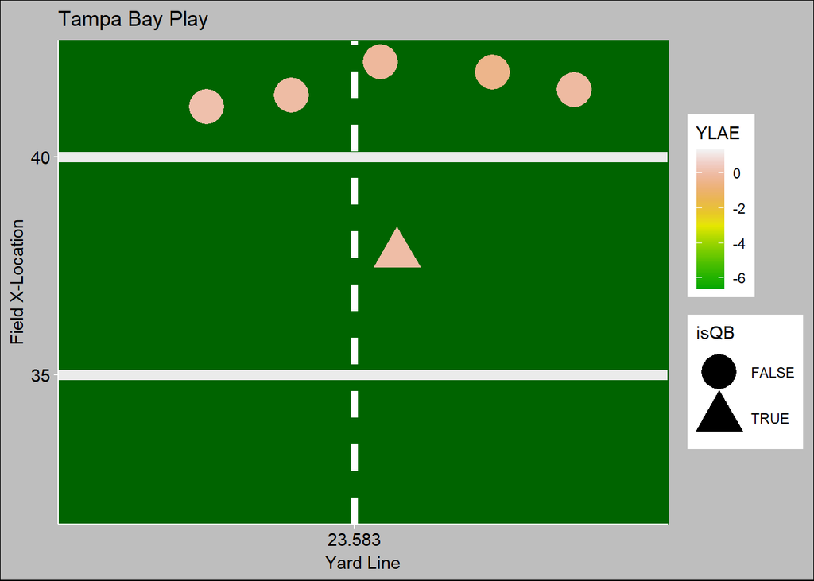

```r
example_play <- getMutData(week1) %>%
  filter(playId == 97)

field_theme <- function(){
  font <- "Georgia"
  theme_bw() %+replace%
    theme(
      panel.grid.major.x = element_line(colour = "white", linetype = "dashed", size = 2),
      panel.grid.minor.x = element_line(colour = "white"),
      panel.grid.major.y = element_line(size = 3),
      panel.background = element_rect(fill = "darkgreen"),
      panel.border = element_rect(color = "darkgreen", fill = NA),
      axis.line = element_line(color = "white"),
      axis.ticks = element_line(color = "white"),
      axis.text = element_text(color = "black"),
      plot.background = element_rect(fill = "gray")
    )
}

play_anim1 <- ggplot(example_play, aes(y = x.normal, x = y.normal, shape = isQB, colour = YLAE)) + geom_point(size = 10) + field_theme() + scale_y_continuous(minor_breaks = seq(0, 100, 5), breaks = seq(0, 100, 5)) + scale_x_continuous(breaks = c(0, 23.583, 29.717, 53.3)) +
  transition_time(frameId) + xlab("Yard Line") + ylab("Field X-Location") + ggtitle("Tampa Bay Play") + scale_colour_gradientn(colours = terrain.colors(12))

play_anim1
```

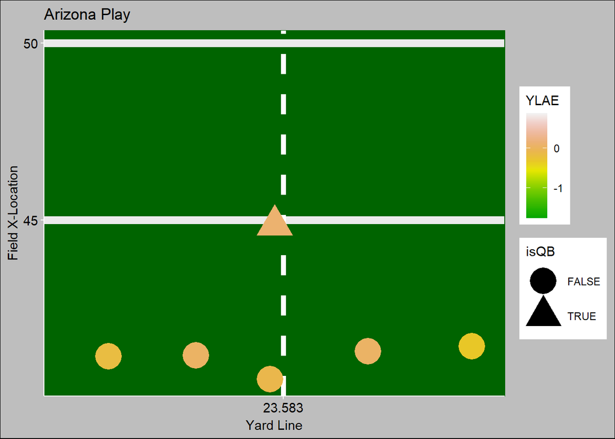

```r
example_play2 <- getMutData(week1) %>%
  filter(gameId == 2021091207, playId == 253)

play_anim2 <- ggplot(example_play2, aes(y = x.normal, x = y.normal, shape = isQB, colour = YLAE)) + geom_point(size = 10) + field_theme() + scale_y_continuous(minor_breaks = seq(0, 100, 5), breaks = seq(0, 100, 5)) + scale_x_continuous(breaks = c(0, 23.583, 29.717, 53.3)) +
  transition_time(frameId) + xlab("Yard Line") + ylab("Field X-Location") + ggtitle("Arizona Play") + scale_colour_gradientn(colours = terrain.colors(12))

play_anim2
```

It’s subtle, but Kyler drifts away from his line, improving their YLAE and helping out there AYLAE.

## Conclusions

Before recently, there was no stat or way to measure lineman performance in the NFL. Sure, we could look at sacks allowed, but that doesn’t tell the full story; can we only measure the bad? Is there a way to measure good blocking?

YLAE provides a meaningful stat to compare lineman performance on pass plays. Now, we can look and evaluate which linemen are providing meaningful protection away from their QB. We can see who’s firmly holding their ground and who’s giving it up. I believe that YLAE is a great way to evaluate linemen on pass plays and to be able to make meaningful comparisons across them without only highlighting the bad. I think it has some errors, like how it biases mobile QBs that create space from the pocket with their legs, but overall, I believe it has the potential to become one of the best modern statistics for linemen.

Thank you for reading my submission!